# Exercise4

# Full model

2. Carry out a multiple linear regression containing all variables. Does the model fit well? Check the residuals.

```r
pollution.fit <- lm(Mortality ~ ., data=pollution)
summary(pollution.fit)
```

```
##
## Call:
## lm(formula = Mortality ~ ., data = pollution)
##
## Residuals:
##     Min      1Q  Median      3Q     Max
## -68.893 -20.704   0.586  24.129  74.604
##
## Coefficients:
##               Estimate Std. Error t value Pr(>|t|)
## (Intercept)  1.297e+03  2.934e+02   4.422 6.32e-05 ***
## JanTemp     -2.368e+00  8.851e-01  -2.676   0.0104 *
## JulyTemp    -1.752e+00  2.031e+00  -0.863   0.3931
## RelHum       3.420e-01  1.059e+00   0.323   0.7482
## Rain         1.493e+00  5.898e-01   2.532   0.0150 *
## Educ        -1.000e+01  9.087e+00  -1.101   0.2771
## Dens         4.525e-03  4.223e-03   1.072   0.2897
## NonWhite     5.152e+00  1.002e+00   5.143 6.01e-06 ***
## WhiteCollar -1.883e+00  1.198e+00  -1.572   0.1232
## logPop       4.391e+00  7.714e+00   0.569   0.5721
## House       -4.574e+01  3.939e+01  -1.161   0.2518
## Income      -6.892e-04  1.334e-03  -0.516   0.6081
## logHC       -2.204e+01  1.523e+01  -1.447   0.1550
## logNOx       3.397e+01  1.425e+01   2.384   0.0215 *
## logSO2      -3.687e+00  7.359e+00  -0.501   0.6189
## ---
## Signif. codes:  0 '***' 0.001 '**' 0.01 '*' 0.05 '.' 0.1 ' ' 1
##
## Residual standard error: 34.48 on 44 degrees of freedom
## Multiple R-squared:  0.7685, Adjusted R-squared:  0.6949
## F-statistic: 10.43 on 14 and 44 DF,  p-value: 8.793e-10
```

Check the residuals

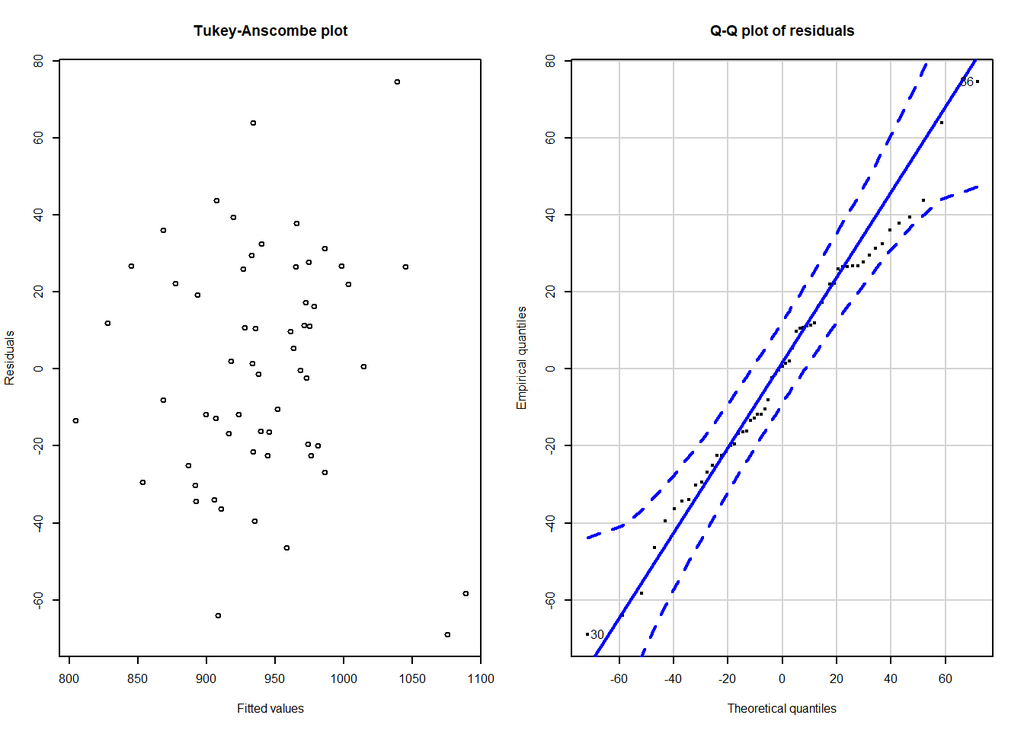

```
## [1] 36 30
```

```r
par(mfrow = c(1, 2), cex = 0.5)

# Are the residuals fluctuating randomly or do they follow a pattern ?
plot(fitted(pollution.fit),
     resid(pollution.fit),
     xlab = "Fitted values",
     ylab = "Residuals",
     main = "Tukey-Anscombe plot")
qqPlot(resid(pollution.fit),
       dist = "norm",
       mean = mean(resid(pollution.fit)),
       sd = sd(resid(pollution.fit)),
       xlab = "Theoretical quantiles",
       ylab = "Empirical quantiles",
       main = "Q-Q plot of residuals")
```

# Reduced model

3. Now take all the non-significant variables out of the model and compute the regression again. Compare your results to part b.).

```r
pollution.fit2 <- lm(Mortality ~ JanTemp + Rain + NonWhite + logNOx, data=pollution)
summary(pollution.fit2)
```

```
##
## Call:
## lm(formula = Mortality ~ JanTemp + Rain + NonWhite + logNOx,
##     data = pollution)
##
## Residuals:
##     Min      1Q  Median      3Q     Max
## -64.946 -22.658  -1.435  19.769  92.049
##
## Coefficients:
##             Estimate Std. Error t value Pr(>|t|)
## (Intercept) 838.1347    27.9499  29.987  < 2e-16 ***
## JanTemp      -2.4322     0.5220  -4.659 2.11e-05 ***
## Rain          2.2528     0.4857   4.639 2.27e-05 ***
## NonWhite      4.3129     0.6479   6.657 1.48e-08 ***
## logNOx       20.2033     4.6113   4.381 5.47e-05 ***
## ---
## Signif. codes:  0 '***' 0.001 '**' 0.01 '*' 0.05 '.' 0.1 ' ' 1
##
## Residual standard error: 35.62 on 54 degrees of freedom
## Multiple R-squared:  0.6968, Adjusted R-squared:  0.6743
## F-statistic: 31.02 on 4 and 54 DF,  p-value: 2.018e-13
```

Check the residuals with the second model

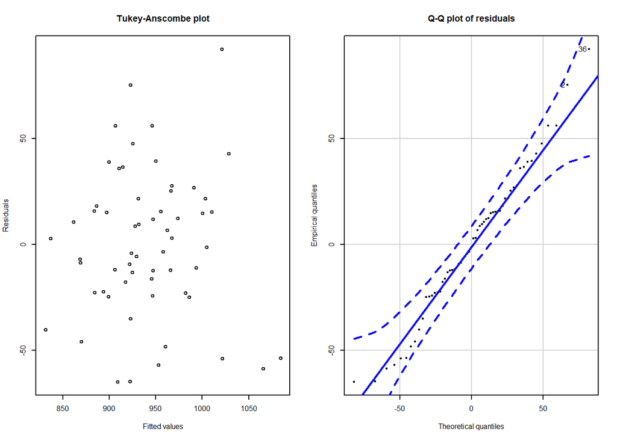

```
## [1] 36  2
```

```r
par(mfrow = c(1, 2), cex = 0.5)

# Are the residuals fluctuating randomly or do they follow a pattern ?
plot(fitted(pollution.fit2),
     resid(pollution.fit2),
     xlab = "Fitted values",
     ylab = "Residuals",
     main = "Tukey-Anscombe plot")
qqPlot(resid(pollution.fit2),
       dist = "norm",
       mean = mean(resid(pollution.fit2)),
       sd = sd(resid(pollution.fit2)),
       xlab = "Theoretical quantiles",
       ylab = "Empirical quantiles",
       main = "Q-Q plot of residuals")
```

# Likelihood ration test (optional)

Is an object of class “anova” which contains the log-likelihood, degrees of freedom, the difference in degrees of freedom, likelihood ratio Chi-squared statistic and corresponding p value.

```r
lrtest(pollution.fit,pollution.fit2)
```

```
## Likelihood ratio test
##
## Model 1: Mortality ~ JanTemp + JulyTemp + RelHum + Rain + Educ + Dens +
##     NonWhite + WhiteCollar + logPop + House + Income + logHC +
##     logNOx + logSO2
## Model 2: Mortality ~ JanTemp + Rain + NonWhite + logNOx
##   #Df  LogLik  Df  Chisq Pr(>Chisq)
## 1  16 -283.95
## 2   6 -291.91 -10 15.931     0.1016
```